# CS 422: Homework 2

Practicum problems

Javier Moreno Sanchez de las Matas

## 2.1 Decission tree classification

```r
library(dplyr)
library(rpart)
library(caret)
library(e1071)
library(rpart.plot)
library(ROCR)
library(randomForest)
library(arules)
rm(list=ls())
setwd("/Users/JavierMoreno/Desktop/Chicago/courses/CS422 Data Mining/hw2")
adultTrain.df <- read.csv("adult-train.csv", header=T, sep=",")
adultTest.df <- read.csv("adult-test.csv", header=T, sep=",")
set.seed(1122)
```

### a)

#### We observe that the attributes that have “?” in them are workclass, occupation and native_country for both the train and test datasets and we clean the datasets removing the rows containing “?”

```r
sum(adultTrain.df$workclass == "?")
```

```
[1] 1836
```

```r
sum(adultTrain.df$occupation == "?")
```

```
[1] 1843
```

```r
sum(adultTrain.df$native_country == "?")
```

```
[1] 583
```

```r
sum(adultTest.df$workclass == "?")
```

```
[1] 963
```

```r
sum(adultTest.df$occupation == "?")
```

```
[1] 966
```

```r
sum(adultTest.df$native_country == "?")
```

```
[1] 274
```

```r
indexes <- which(adultTrain.df$workclass=="?")
adultTrain.df <- adultTrain.df[-indexes, ]
indexes <- which(adultTrain.df$occupation=="?")
adultTrain.df <- adultTrain.df[-indexes, ]
indexes <- which(adultTrain.df$native_country=="?")
adultTrain.df <- adultTrain.df[-indexes, ]
indexes <- which(adultTest.df$workclass=="?")
adultTest.df <- adultTest.df[-indexes, ]
indexes <- which(adultTest.df$occupation=="?")
adultTest.df <- adultTest.df[-indexes, ]
indexes <- which(adultTest.df$native_country=="?")
adultTest.df <- adultTest.df[-indexes, ]
```

### b)

#### i. The summary() function gives us some information about the model. As we can see in the variable importance section of it the three attributes with a higher level of significance are relationship, marital_status and capital_gain.

```r
model <- rpart(income ~ ., method="class", data=adultTrain.df)
summary(model)
```

```
Call:
rpart(formula = income ~ ., data = adultTrain.df, method = "class")
  n= 30161

          CP nsplit rel error    xerror        xstd
1 0.12999467      0 1.0000000 1.0000000 0.010001793
2 0.06419819      2 0.7400107 0.7400107 0.008966969
3 0.03729355      3 0.6758125 0.6758125 0.008652716
4 0.01000000      4 0.6385189 0.6385189 0.008457392

Variable importance
  relationship marital_status   capital_gain      education  education_num            sex     occupation            age
            24             23             10              9              9              8              7              5
hours_per_week
             3

Node number 1: 30161 observations,    complexity param=0.1299947
  predicted class=<=50K  expected loss=0.2489307  P(node) =1
    class counts: 22653  7508
   probabilities: 0.751 0.249
  left son=2 (16292 obs) right son=3 (13869 obs)
  Primary splits:
      relationship   splits as  RLLLLR, improve=2277.164, (0 missing)
      marital_status splits as  LRRLLLL, improve=2244.398, (0 missing)
      capital_gain   < 5119   to the left,  improve=1540.825, (0 missing)
      education      splits as  LLLLLLLLLRRLRLRL, improve=1193.769, (0 missing)
      education_num  < 12.5   to the left,  improve=1193.769, (0 missing)
  Surrogate splits:
      marital_status splits as  LRRLLLL, agree=0.993, adj=0.984, (0 split)
      sex            splits as  LR, agree=0.691, adj=0.328, (0 split)
      age            < 33.5   to the left,  agree=0.645, adj=0.229, (0 split)
      occupation     splits as  -LLRRRLLLLRRLLR, agree=0.620, adj=0.175, (0 split)
      hours_per_week < 43.5   to the left,  agree=0.604, adj=0.138, (0 split)

Node number 2: 16292 observations,    complexity param=0.03729355
  predicted class=<=50K  expected loss=0.06966609  P(node) =0.5401678
    class counts: 15157  1135
   probabilities: 0.930 0.070
  left son=4 (15992 obs) right son=5 (300 obs)
  Primary splits:
```

[output cut: 45 more lines]

```

Node number 7: 4150 observations
  predicted class=>50K   expected loss=0.2648193  P(node) =0.1375949
    class counts:  1099  3051
   probabilities: 0.265 0.735

Node number 12: 9219 observations
  predicted class=<=50K  expected loss=0.3070832  P(node) =0.3056596
    class counts:  6388  2831
   probabilities: 0.693 0.307

Node number 13: 500 observations
  predicted class=>50K   expected loss=0.018  P(node) =0.0165777
    class counts:     9   491
   probabilities: 0.018 0.982
```

#### ii. The first split is done on the relationship predictor, which is the most important variable. We can see it graphically plotting the tree:

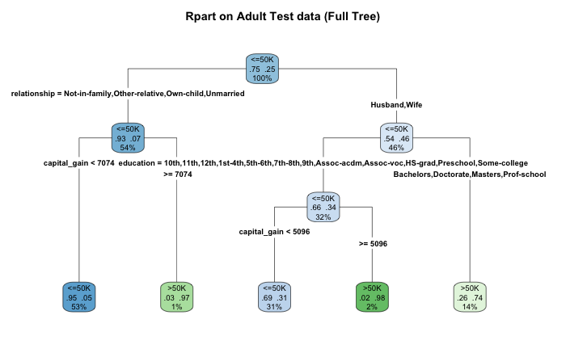

```r
rpart.plot(model, extra=104, fallen.leaves = T, type=4, main="Rpart on Adult Test data (Full Tree)")
```

#### In the summary of the model we see that the predicted class in the first node is <=50k and the distribution of observation between the “<=50K” and “>50K” classes is 75.1% and 24.9% respectively.

### c)

#### i. We run the confusionMatrix() function and obtain the following output:

```r
pred <- predict(model, adultTest.df, type="class")
confusionMatrix(pred, as.factor(adultTest.df[, 15]))
```

```
Confusion Matrix and Statistics

          Reference
Prediction <=50K  >50K
     <=50K 10772  1837
     >50K    588  1863

               Accuracy : 0.839
                 95% CI : (0.833, 0.8448)
    No Information Rate : 0.7543
    P-Value [Acc > NIR] : < 2.2e-16

                  Kappa : 0.5098
 Mcnemar's Test P-Value : < 2.2e-16

            Sensitivity : 0.9482
            Specificity : 0.5035
         Pos Pred Value : 0.8543
         Neg Pred Value : 0.7601
             Prevalence : 0.7543
         Detection Rate : 0.7153
   Detection Prevalence : 0.8373
      Balanced Accuracy : 0.7259

       'Positive' Class : <=50K
```

#### We can see that our model has a balanced accuracy of 72.6%.

#### ii. The balanced error rate of the model is 0.274.

#### iii. Sensitivity is the ability of our model to correctly identify the true positives, whereas test specificity is the ability of the test to correctly identify those without the true negative. Since in our confusion matrix the positive class is “<=50k” we observe a total of 10,772 true positives, 1,837 false positives, 1,863 true negatives and 588 false negatives leading to a sensitivity of 94.8% and a specificity of 50.4%.

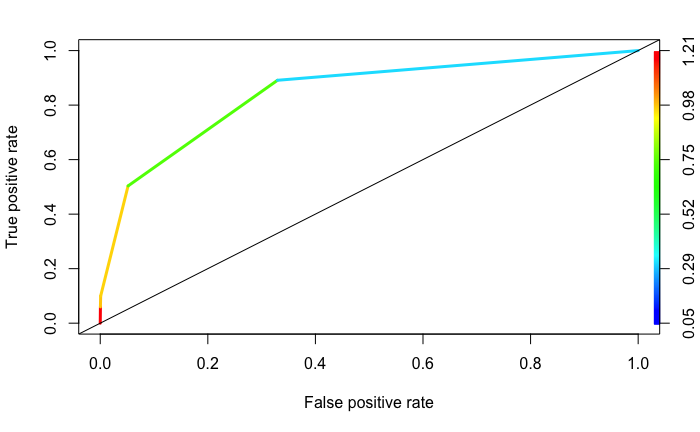

```r
pred.rocr <- predict(model, newdata=adultTest.df, type="prob")[,2]
f.pred <- prediction(pred.rocr, adultTest.df$income)
f.perf <- performance(f.pred, "tpr", "fpr")
plot(f.perf, colorize=T, lwd=3)
abline(0,1)
```

```r
auc <- performance(f.pred, measure = "auc")
cat(paste("The area under curve (AUC) for this model is ", round(auc@y.values[[1]], 3)))
```

```
The area under curve (AUC) for this model is  0.843
```

#### iv. AUC is the Area Under Curve and is a measure of the accuracy of the test. In our case the AUC is 0.843, being 1 the maximum possible value.

### d)

#### The complexity table of our model is the one that follows:

```r
options("digits"=5)
printcp(model)
```

```
Classification tree:
rpart(formula = income ~ ., data = adultTrain.df, method = "class")

Variables actually used in tree construction:
[1] capital_gain education    relationship

Root node error: 7508/30161 = 0.249

n= 30161

      CP nsplit rel error xerror    xstd
1 0.1300      0     1.000  1.000 0.01000
2 0.0642      2     0.740  0.740 0.00897
3 0.0373      3     0.676  0.676 0.00865
4 0.0100      4     0.639  0.639 0.00846
```

```r
cpx=model$cptable[which.min(model$cptable[,"xerror"]), "CP"]
cpx
```

```
[1] 0.01
```

#### We see how the cross-validation error (xerror) decreases for each rows. Therefore the tree would not benefit from a pruning.

### e)

#### i. The training data set has 22,653 “<=50K” and 7,508 “>50K” observations.

```r
under50observations <- sum(adultTrain.df$income == "<=50K")
over50observations <- sum(adultTrain.df$income == ">50K")
under50observations
```

```
[1] 22653
```

```r
over50observations
```

```
[1] 7508
```

```r
indexesUnder50 <- which(adultTrain.df$income=="<=50K")
indexesOver50 <- which(adultTrain.df$income==">50K")
indexesUnder50 <- sample(indexesUnder50, over50observations)
indexes <- c(indexesUnder50, indexesOver50)
adultTrain.df <- adultTrain.df[indexes, ]
sum(adultTrain.df$income == "<=50K")
```

```
[1] 7508
```

```r
sum(adultTrain.df$income == ">50K")
```

```
[1] 7508
```

```r
model2 <- rpart(income ~ ., method="class", data=adultTrain.df)
summary(model2)
```

```
Call:
rpart(formula = income ~ ., data = adultTrain.df, method = "class")
  n= 15016

      CP nsplit rel error xerror    xstd
1 0.5125      0     1.000  1.020 0.00816
2 0.0393      1     0.487  0.487 0.00701
3 0.0116      2     0.448  0.448 0.00681
4 0.0115      6     0.396  0.407 0.00657
5 0.0100      7     0.385  0.394 0.00649

Variable importance
  relationship marital_status     occupation            sex            age   capital_gain hours_per_week      education
            28             28             10             10              8              7              3              2
 education_num
             2

Node number 1: 15016 observations,    complexity param=0.513
  predicted class=<=50K  expected loss=0.5  P(node) =1
    class counts:  7508  7508
   probabilities: 0.500 0.500
  left son=2 (6118 obs) right son=3 (8898 obs)
  Primary splits:
      relationship   splits as  RLLLLR, improve=2040, (0 missing)
      marital_status splits as  LRRLLLL, improve=2030, (0 missing)
      age            < 29.5  to the left,  improve=1010, (0 missing)
      education      splits as  LLLLLLLLLRRLRLRL, improve= 875, (0 missing)
      education_num  < 12.5  to the left,  improve= 875, (0 missing)
  Surrogate splits:
      marital_status splits as  LRRLLLL, agree=0.994, adj=0.984, (0 split)
      sex            splits as  LR, agree=0.732, adj=0.343, (0 split)
      age            < 29.5  to the left,  agree=0.703, adj=0.271, (0 split)
      occupation     splits as  -LLRRRLRLLRRRRR, agree=0.665, adj=0.178, (0 split)
      hours_per_week < 39.5  to the left,  agree=0.643, adj=0.123, (0 split)

Node number 2: 6118 observations,    complexity param=0.0393
  predicted class=<=50K  expected loss=0.186  P(node) =0.407
    class counts:  4983  1135
   probabilities: 0.814 0.186
  left son=4 (5765 obs) right son=5 (353 obs)
```

[output cut: 112 more lines]

```
      relationship   splits as  R----L, agree=0.782, adj=0.050, (0 split)
      sex            splits as  LR, agree=0.782, adj=0.050, (0 split)
      age            < 66.5  to the right, agree=0.777, adj=0.028, (0 split)
      hours_per_week < 31    to the left,  agree=0.776, adj=0.026, (0 split)
      native_country splits as  -RRRRR--RR-RRRL--R-RRRRL-LR-RRRRL-L-RRRRL, agree=0.774, adj=0.015, (0 split)

Node number 102: 464 observations
  predicted class=<=50K  expected loss=0.407  P(node) =0.0309
    class counts:   275   189
   probabilities: 0.593 0.407

Node number 103: 1558 observations
  predicted class=>50K   expected loss=0.381  P(node) =0.104
    class counts:   594   964
   probabilities: 0.381 0.619
```

#### iii. The confusion matrix of this new model is:

```r
pred <- predict(model2, adultTest.df, type="class")
confusionMatrix(pred, as.factor(adultTest.df[, 15]))
```

```
Confusion Matrix and Statistics

          Reference
Prediction <=50K >50K
     <=50K  8879  609
     >50K   2481 3091

               Accuracy : 0.795
                 95% CI : (0.788, 0.801)
    No Information Rate : 0.754
    P-Value [Acc > NIR] : <2e-16

                  Kappa : 0.527
 Mcnemar's Test P-Value : <2e-16

            Sensitivity : 0.782
            Specificity : 0.835
         Pos Pred Value : 0.936
         Neg Pred Value : 0.555
             Prevalence : 0.754
         Detection Rate : 0.590
   Detection Prevalence : 0.630
      Balanced Accuracy : 0.809

       'Positive' Class : <=50K
```

#### The balanced accuracy of this new model is 80.9%.

#### The balanced error rate of the model is 0.191.

#### The sensitivity is 78.2% and the specificity 83.5%.

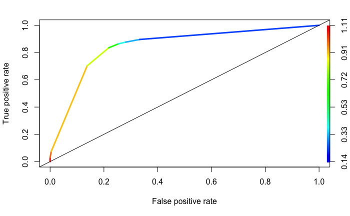

```r
pred.rocr <- predict(model2, newdata=adultTest.df, type="prob")[,2]
f.pred <- prediction(pred.rocr, adultTest.df$income)
f.perf <- performance(f.pred, "tpr", "fpr")
plot(f.perf, colorize=T, lwd=3)
abline(0,1)
```

```r
auc <- performance(f.pred, measure = "auc")
cat(paste("The area under curve (AUC) for this model is ", round(auc@y.values[[1]], 3)))
```

```
The area under curve (AUC) for this model is  0.846
```

### a)

```r
adultTrain.df <- read.csv("adult-train.csv", header=T, sep=",")
adultTest.df <- read.csv("adult-test.csv", header=T, sep=",")
set.seed(1122)
indexes <- which(adultTrain.df$workclass=="?")
adultTrain.df <- adultTrain.df[-indexes, ]
indexes <- which(adultTrain.df$occupation=="?")
adultTrain.df <- adultTrain.df[-indexes, ]
indexes <- which(adultTrain.df$native_country=="?")
adultTrain.df <- adultTrain.df[-indexes, ]
indexes <- which(adultTest.df$workclass=="?")
adultTest.df <- adultTest.df[-indexes, ]
indexes <- which(adultTest.df$occupation=="?")
adultTest.df <- adultTest.df[-indexes, ]
indexes <- which(adultTest.df$native_country=="?")
adultTest.df <- adultTest.df[-indexes, ]
modelRF <- randomForest(income ~ ., data=adultTrain.df, importance = T)
pred <- predict(modelRF, adultTest.df, type="class")
confusionMatrix(pred, as.factor(adultTest.df$income))
```

```
Confusion Matrix and Statistics

          Reference
Prediction <=50K  >50K
     <=50K 10563  1340
     >50K    797  2360

               Accuracy : 0.858
                 95% CI : (0.852, 0.864)
    No Information Rate : 0.754
    P-Value [Acc > NIR] : <2e-16

                  Kappa : 0.597
 Mcnemar's Test P-Value : <2e-16

            Sensitivity : 0.930
            Specificity : 0.638
         Pos Pred Value : 0.887
         Neg Pred Value : 0.748
             Prevalence : 0.754
         Detection Rate : 0.701
   Detection Prevalence : 0.790
      Balanced Accuracy : 0.784

       'Positive' Class : <=50K
```

#### i. The balanced accuracy of the model is 78.4%

#### ii.The accuracy of the model is 85.8%

#### iii. The sensitivity of the model is 93.0% and the specificity is 63.8%

#### iv. 11,903 observations are labeled “<=50K” and only 3,157 are labeled “>50K”.

#### v. The model has a very high sensitivity, which indicates that it is really good at finding true positive instances, but on the other hand, it does not find true negative instances correctly, because it predicts more often that a observation belongs to the “<=50K” class, the positive class.

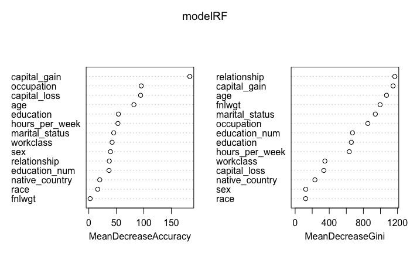

```r
varImpPlot(modelRF)
```

#### vi. For MeanDecreaseAccuracy the most important variable is capital_gain and the least one is fnlwgt. And for ManDecreaseGini the most important variable is relationship and the least one is race.

```r
print(modelRF)
```

```
Call:
 randomForest(formula = income ~ ., data = adultTrain.df, importance = T)
               Type of random forest: classification
                     Number of trees: 500
No. of variables tried at each split: 3

        OOB estimate of  error rate: 13.8%
Confusion matrix:
      <=50K >50K class.error
<=50K 21096 1557      0.0687
>50K   2599 4909      0.3462
```

#### vii. Running the command “print(modelRF)” we can see that the model tried 3 variables at each split.

### b)

```
mtry = 3  OOB error = 13.86%
Searching left ...
mtry = 2    OOB error = 13.71%
0.011 0.01
Searching right ...
mtry = 4    OOB error = 14.14%
-0.0319 0.01
```

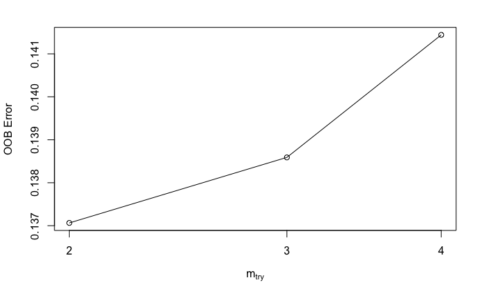

```r
mtry <- tuneRF(select(adultTrain.df, age, workclass, fnlwgt, education, education_num, marital_status, occupation, relationship, race, sex, capital_gain, capital_loss, hours_per_week, native_country), adultTrain.df$income, ntreeTry=500, stepFactor=1.5,improve=0.01, trace=TRUE, plot=TRUE)
```

```r
print(mtry)
```

```
      mtry OOBError
2.OOB    2    0.137
3.OOB    3    0.139
4.OOB    4    0.141
```

#### i. The default value of mtry given the number of predictors of the model is 3, since is the tuneRF() function starts with that value.

#### ii. We can see that the optimal value for mtry is 2 since it has the lowest error.

```r
modelRFOptimal <- randomForest(income ~ ., data=adultTrain.df, importance = T, mtry = 2)
pred2 <- predict(modelRFOptimal, adultTest.df, type="class")
confusionMatrix(pred2, as.factor(adultTest.df$income))
```

```
Confusion Matrix and Statistics

          Reference
Prediction <=50K  >50K
     <=50K 10617  1358
     >50K    743  2342

               Accuracy : 0.86
                 95% CI : (0.855, 0.866)
    No Information Rate : 0.754
    P-Value [Acc > NIR] : <2e-16

                  Kappa : 0.601
 Mcnemar's Test P-Value : <2e-16

            Sensitivity : 0.935
            Specificity : 0.633
         Pos Pred Value : 0.887
         Neg Pred Value : 0.759
             Prevalence : 0.754
         Detection Rate : 0.705
   Detection Prevalence : 0.795
      Balanced Accuracy : 0.784

       'Positive' Class : <=50K
```

#### iii. 1. The balanced accuracy of the model is 78.4%

#### iii. 2. The accuracy of the model is 86%

#### iii. 3. The sensitivity of the model is 93.5% and the specificity is 63.3%

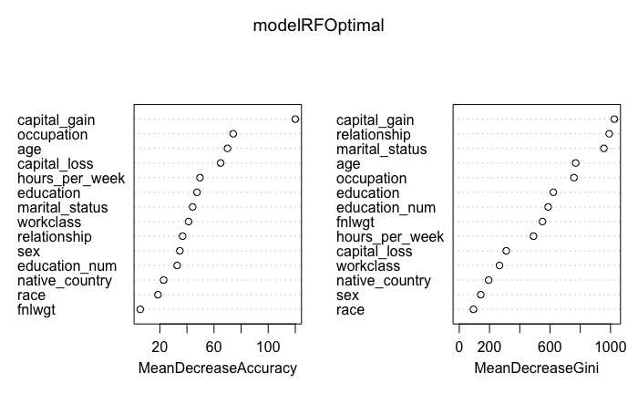

```r
varImpPlot(modelRFOptimal)
```

#### iii. 4. As before, for MeanDecreaseAccuracy the most important variable is capital_gain and the least one is fnlwgt And for ManDecreaseGini the most important variable is now also capital_gain and the least one is still race.

#### iv. We observe that the performance of the model has not improved by using the optimal value of mtry since the error between the two values of mtry only differs in 0.002.

## 2.3 Association rules

```r
groceries.df <- read.transactions("groceries.csv", format = "basket", sep = ",")
apriori(groceries.df)
```

```
Apriori

Parameter specification:
```

|  | confidence | minval | smax | arem | aval | originalSupport | maxtime | support | minlen | maxlen | target | ext |
| --- | --- | --- | --- | --- | --- | --- | --- | --- | --- | --- | --- | --- |
|  | 0.8 | 0.1 | 1 | none | FALSE | TRUE | 5 | 0.1 | 1 | 10 | rules | FALSE |

```
Algorithmic control:
```

|  | filter | tree | heap | memopt | load | sort | verbose |
| --- | --- | --- | --- | --- | --- | --- | --- |
|  | 0.1 | TRUE | TRUE | FALSE | TRUE | 2 | TRUE |

```
Absolute minimum support count: 983

set item appearances ...[0 item(s)] done [0.00s].
set transactions ...[169 item(s), 9835 transaction(s)] done [0.01s].
sorting and recoding items ... [8 item(s)] done [0.00s].
creating transaction tree ... done [0.00s].
checking subsets of size 1 2 done [0.00s].
writing ... [0 rule(s)] done [0.00s].
creating S4 object  ... done [0.00s].
set of 0 rules
```

#### i. With the default configuration of the method apriori() we obtain 0 rules.

```r
rules <- apriori(groceries.df, parameter = list(supp = 0.001))
```

```
Apriori

Parameter specification:
```

|  | confidence | minval | smax | arem | aval | originalSupport | maxtime | support | minlen | maxlen | target | ext |
| --- | --- | --- | --- | --- | --- | --- | --- | --- | --- | --- | --- | --- |
|  | 0.8 | 0.1 | 1 | none | FALSE | TRUE | 5 | 0.001 | 1 | 10 | rules | FALSE |

```
Algorithmic control:
```

|  | filter | tree | heap | memopt | load | sort | verbose |
| --- | --- | --- | --- | --- | --- | --- | --- |
|  | 0.1 | TRUE | TRUE | FALSE | TRUE | 2 | TRUE |

```
Absolute minimum support count: 9

set item appearances ...[0 item(s)] done [0.00s].
set transactions ...[169 item(s), 9835 transaction(s)] done [0.01s].
sorting and recoding items ... [157 item(s)] done [0.00s].
creating transaction tree ... done [0.00s].
checking subsets of size 1 2 3 4 5 6 done [0.04s].
writing ... [410 rule(s)] done [0.00s].
creating S4 object  ... done [0.01s].
```

#### ii. With a support value of 0.001 we obtain 410 rules.

```r
head(sort(itemFrequency(groceries.df, type = "absolute"), decreasing = T))
```

```
      whole milk other vegetables       rolls/buns             soda           yogurt    bottled water
            2513             1903             1809             1715             1372             1087
```

#### iii. The most frequent item is the whole milk. It appears 2513 times.

```r
tail(sort(itemFrequency(groceries.df, type = "absolute"), decreasing = T))
```

```
       frozen chicken                  bags       kitchen utensil preservation products             baby food
                    6                     4                     4                     2                     1
 sound storage medium
                    1
```

#### iv. The least frequent item is the sound storage medium . It appears only 1 time.

#### v. The top 5 rules sorted by support are:

```r
inspect(sort(rules, decreasing = T, by="support")[1:5])
```

|  | lhs |  | rhs | support | confidence | lift | count |
| --- | --- | --- | --- | --- | --- | --- | --- |
| [1] | {citrus fruit,root vegetables,tropical fruit,whole milk} | => | {other vegetables} | 0.00315 | 0.886 | 4.58 | 31 |
| [2] | {curd,domestic eggs,other vegetables} | => | {whole milk} | 0.00285 | 0.824 | 3.22 | 28 |
| [3] | {curd,hamburger meat} | => | {whole milk} | 0.00254 | 0.806 | 3.16 | 25 |
| [4] | {herbs,rolls/buns} | => | {whole milk} | 0.00244 | 0.800 | 3.13 | 24 |
| [5] | {herbs,tropical fruit} | => | {whole milk} | 0.00234 | 0.821 | 3.21 | 23 |

#### vi. The top 5 rules sorted by confidence are:

```r
inspect(sort(rules, decreasing = T, by="confidence")[1:5])
```

|  | lhs |  | rhs | support | confidence | lift | count |
| --- | --- | --- | --- | --- | --- | --- | --- |
| [1] | {rice,sugar} | => | {whole milk} | 0.00122 | 1 | 3.91 | 12 |
| [2] | {canned fish,hygiene articles} | => | {whole milk} | 0.00112 | 1 | 3.91 | 11 |
| [3] | {butter,rice,root vegetables} | => | {whole milk} | 0.00102 | 1 | 3.91 | 10 |
| [4] | {flour,root vegetables,whipped/sour cream} | => | {whole milk} | 0.00173 | 1 | 3.91 | 17 |
| [5] | {butter,domestic eggs,soft cheese} | => | {whole milk} | 0.00102 | 1 | 3.91 | 10 |

#### vi. The bottom 5 rules sorted by support are:

```r
inspect(sort(rules, decreasing = F, by="support")[1:5])
```

|  | lhs |  | rhs | support | confidence | lift | count |
| --- | --- | --- | --- | --- | --- | --- | --- |
| [1] | {cereals,curd} | => | {whole milk} | 0.00102 | 0.909 | 3.56 | 10 |
| [2] | {butter,jam} | => | {whole milk} | 0.00102 | 0.833 | 3.26 | 10 |
| [3] | {pastry,sweet spreads} | => | {whole milk} | 0.00102 | 0.909 | 3.56 | 10 |
| [4] | {butter,rice,root vegetables} | => | {whole milk} | 0.00102 | 1.000 | 3.91 | 10 |
| [5] | {other vegetables,rice,tropical fruit} | => | {whole milk} | 0.00102 | 0.833 | 3.26 | 10 |

#### vi. The bottom 5 rules sorted by confidence are:

```r
inspect(sort(rules, decreasing = F, by="confidence")[1:5])
```

|  | lhs |  | rhs | support | confidence | lift | count |
| --- | --- | --- | --- | --- | --- | --- | --- |
| [1] | {curd,turkey} | => | {other vegetables} | 0.00122 | 0.8 | 4.13 | 12 |
| [2] | {fruit/vegetable juice,herbs} | => | {other vegetables} | 0.00122 | 0.8 | 4.13 | 12 |
| [3] | {herbs,rolls/buns} | => | {whole milk} | 0.00244 | 0.8 | 3.13 | 24 |
| [4] | {onions,waffles} | => | {other vegetables} | 0.00122 | 0.8 | 4.13 | 12 |
| [5] | {root vegetables,tropical fruit,turkey} | => | {other vegetables} | 0.00122 | 0.8 | 4.13 | 12 |